# Using covidseir to model COVID-19 in B.C.

Travis Blimkie, Arjun Baghela & Hossameldin Mohammed

May 20, 2021

## Load packages

```r
suppressPackageStartupMessages({
  library(covidseir)
  library(lubridate)
  library(tidyverse)
  # future::plan(future::multisession)
})
```

## Load data

We’re using the BC COVID-19 case data from the BC CDC, downloaded on May 17th, 2021 from this [link](http://www.bccdc.ca/health-info/diseases-conditions/covid-19/data).

```r
bc_data <-
  read_csv("../bc_data/BCCDC_COVID19_Dashboard_Case_Details.csv") %>%
  janitor::clean_names()

bc_data_daily_cases <- bc_data %>%
  group_by(reported_date) %>%
  summarise(daily_cases = n())
```

## Plot trends in case data

### Daily Cases, January 29 2020 - May 17 2021

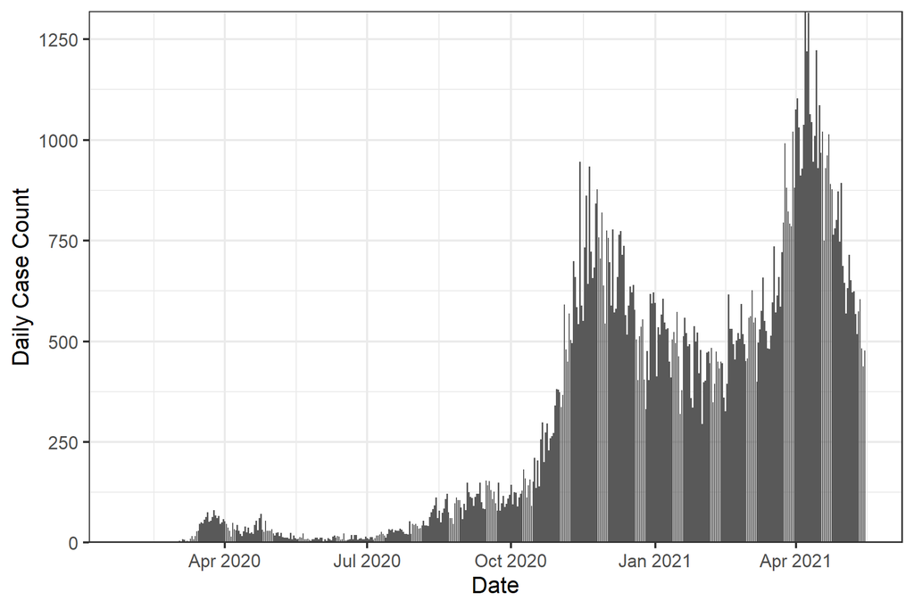

```r
ggplot(bc_data_daily_cases, aes(reported_date, daily_cases)) +
  geom_col() +
  theme_bw(base_size = 16) +
  scale_y_continuous(expand = c(0, 0)) +
  labs(
    x = "Date",
    y = "Daily Case Count"
  )
```

### Daily cases, January 29 2020 - May 17 2021, coloured by region

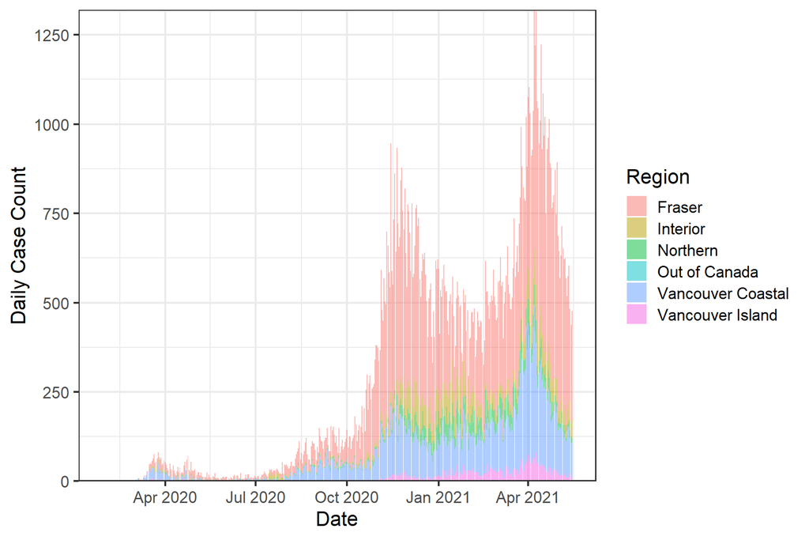

```r
bc_data %>%
  group_by(reported_date, ha) %>%
  summarise(daily_cases = n()) %>%
  ggplot(., aes(reported_date, daily_cases, fill = ha)) +
  geom_col(alpha = 0.5) +
  theme_bw(base_size = 16) +
  scale_y_continuous(expand = c(0, 0)) +
  labs(
    x = "Date",
    y = "Daily Case Count",
    fill = "Region"
  )
```

### Daily cases, January 29 - December 31 2020

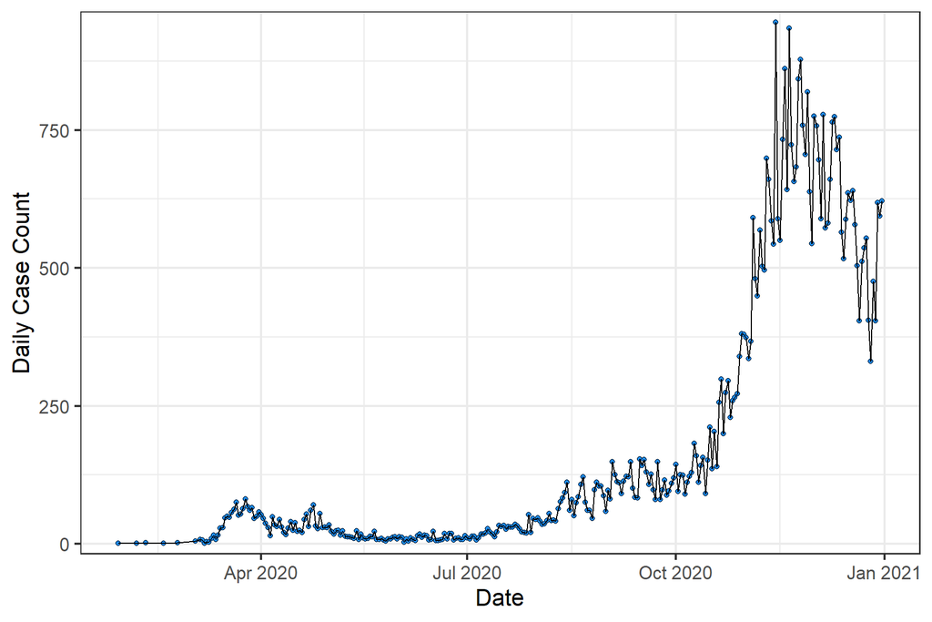

```r
bc_data_daily_cases %>%
  filter(reported_date <= ymd("20201231")) %>%
  ggplot(., aes(reported_date, daily_cases)) +
  geom_point(pch = 21, fill = "dodgerblue", colour = "black") +
  geom_line() +
  theme_bw(base_size = 16) +
  scale_y_continuous(expand = c(0, 20)) +
  labs(
    x = "Date",
    y = "Daily Case Count"
  )
```

### Daily cases, September 1 - December 31 2020, with highlighted dates

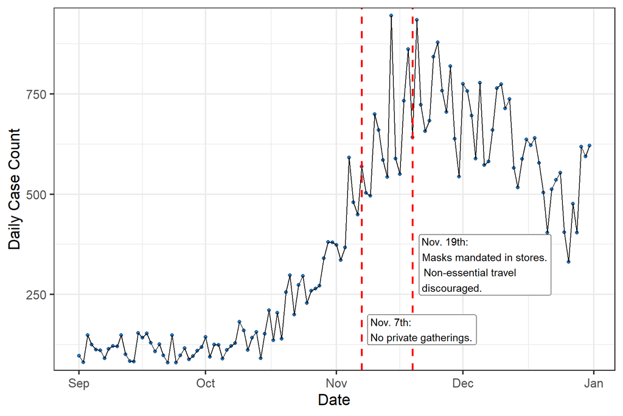

```r
major_restrictions <- c(
  "2020-11-07" = " Nov. 7th:\nNo private gatherings.",
  "2020-11-19" = " Nov. 19th:\nMasks mandated in stores.\n Non-essential travel\n discouraged."
  # "2021-03-11" = "Outdoor gathering \nof 10 people allowed",
  # "2021-03-29" = "\n\n\nNo indoor dining\nNo indoor group activity\nMasks grades 4-12"
)

major_restrictions_tbl <- tibble(
  date = names(major_restrictions),
  text = major_restrictions,
  yval = c(200, 400)
)

bc_data_daily_cases %>%
  filter(between(reported_date, ymd("20200901"), ymd("20201231"))) %>%
  ggplot(., aes(reported_date, daily_cases)) +
  geom_point(pch = 21, fill = "dodgerblue", colour = "black") +
  geom_line() +
  theme_bw(base_size = 16) +
  scale_y_continuous(expand = c(0, 20)) +
  labs(
    x = "Date",
    y = "Daily Case Count"
  ) +
  annotate(
    geom = "vline",
    x = ymd(major_restrictions_tbl$date),
    xintercept = ymd(major_restrictions_tbl$date),
    linetype = "dashed",
    colour = "red",
    size = 1
  ) +
  annotate(
    geom = "label",
    x = ymd(major_restrictions_tbl$date),
    y = major_restrictions_tbl$yval,
    label = major_restrictions_tbl$text,
    vjust = 1,
    hjust = -0.05
  )
```

## The starting-point model

```r
model_input_v0 <- bc_data_daily_cases %>%
  filter(reported_date < ymd("20210315")) %>%
  mutate(day = 1:nrow(.))

samp_frac_v0 <- c(
  rep(0.14, 13),
  rep(0.21, 38),
  rep(0.37, 125),
  rep(0.45, nrow(model_input_v0) - (13 + 38 + 125))
)

model_input_v0 <- model_input_v0 %>%
  mutate(
    f_seg = case_when(
      reported_date == ymd("2020-01-29") ~ 0,
      reported_date < ymd("20200501") ~ 1,
      between(reported_date, ymd("2020-05-01"), ymd("2020-06-01")) ~ 2,
      between(reported_date, ymd("2020-06-02"), ymd("2020-11-15")) ~ 3,
      between(reported_date, ymd("2020-11-16"), ymd("2021-01-01")) ~ 4,
      between(reported_date, ymd("2021-01-02"), ymd("2021-05-05")) ~ 5,
      TRUE ~ 9
    )
  )

seir_real_dat_v0 <- fit_seir(
  daily_cases         = model_input_v0$daily_cases,
  f_seg               = model_input_v0$f_seg,
  samp_frac_fixed     = samp_frac_v0,
  days_back           = 60,
  i0_prior            = c(log(8), 1),
  e_prior             = c(0.8, 0.05),
  start_decline_prior = c(log(15), 0.1),
  end_decline_prior   = c(log(22), 0.1),
  f_prior             = rbind(c(0.4, 0.2), c(0.5, 0.2), c(0.6, 0.2), c(0.7, 0.2), c(0.7, 0.2)),
  R0_prior            = c(log(2.95), 0.07),
  N_pop               = 5.1e6,
  fit_type            = "optimizing",
  iter                = 50
)
```

```
Finding the MAP estimate.
```

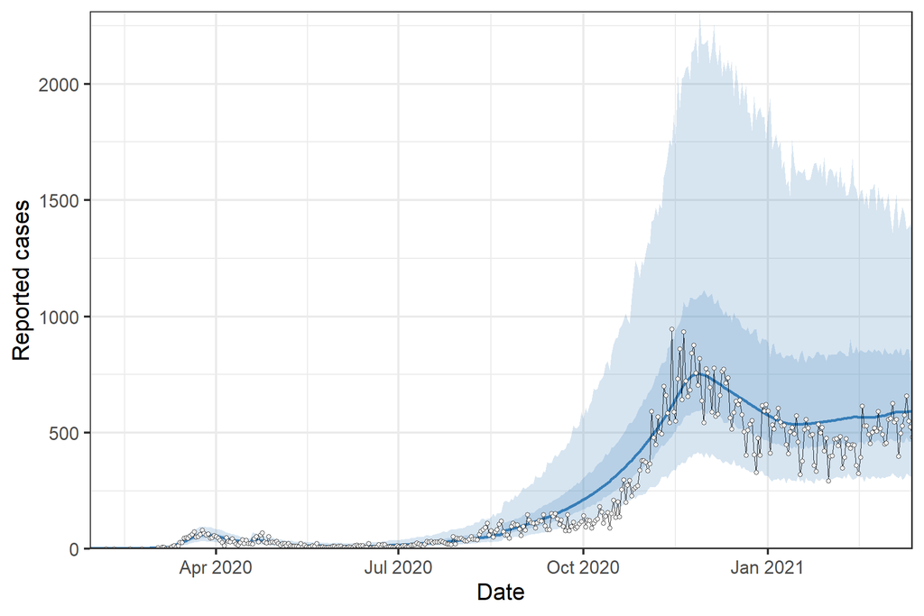

```r
project_real_dat_v0 <- project_seir(seir_real_dat_v0, iter = 1:50)

project_real_tidy_v0 <-
  tidy_seir(project_real_dat_v0, resample_y_rep = 20) %>%
  left_join(., model_input_v0, by = "day")

plot_projection(
  pred_dat     = project_real_tidy_v0,
  obs_dat      = model_input_v0,
  value_column = "daily_cases",
  date_column  = "reported_date",
) +
  theme_bw(base_size = 16) +
  labs(x = "Date")
```

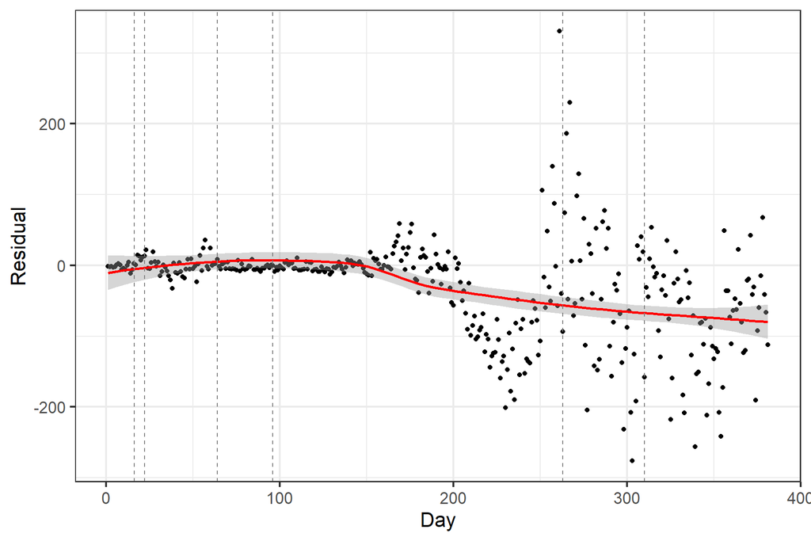

```r
plot_residuals(
  pred_dat      = project_real_tidy_v0,
  obs_dat       = model_input_v0,
  obj           = seir_real_dat_v0,
  value_column  = "daily_cases",
  date_column   = "day",
  type          = c("raw", "quantile"),
  date_function = lubridate::ymd
) +
  theme_bw(base_size = 16) +
  labs(x = "Day")
```

## Research question

In November 2020, the public health authority introduced new measures in an attempt to slow the spread of COVID-19 in the province. These included a mandatory mask policy for all indoor public spaces, travel restrictions and the banning of private gatherings with individuals outside the household. Can we develop a model based on BC’s COVID data to project possible outcomes had these measures been implemented earlier or later?

## Developing a new model

### Parameters of concern

Parameters we need to figure out, in approximate order of importance/priority:

- R0 - I think this should be estimated from our case data for the time range we’re interested in, but I’m not sure how to do this…
- Sampling fraction - the `covidseir` package covered the first 176 days of the model, and I covered the remaining days with a value of 0.45, thinking testing coverage probably increased somewhat…but this number needs to be (ideally) based on some sort of data or public health record
- Distancing dates - these “breakpoints” represent changes in social distancing behaviour, and their number and placement in the time line need to be adjusted
- Days back - needs to be “…sufficiently large tha the results don’t change,” from the `fit_seir` help page. I don’t know what the default is, but I set it to 60 in the above models.
- The social distancing ramp (start- and end-decline prior) could also be tweaked, though I used the values from the vignette which is based on BC data; It is from a shorter time range than what we’re looking at, though it should still be applicable since we’re just extending the end date of the model

### Attempt 1

Since at moment I don’t want to try and figure out how to ignore the social distancing ramp (to allow us to start at a later date, e.g. September), let’s just filter the data to the end of December 2020. And I also reverted to using the vignette’s estimate of R0 in B.C., since at the moment I can’t justify using a different value.

```r
model_input_v1 <- bc_data_daily_cases %>%
  filter(reported_date <= ymd("20201231")) %>%
  mutate(day = 1:nrow(.))

samp_frac_v1 <- c(
  rep(0.14, 13),
  rep(0.21, 38),
  rep(0.37, 125),
  rep(0.45, nrow(model_input_v1) - (13 + 38 + 125))
)

model_input_v1 <- model_input_v1 %>%
  mutate(
    f_seg = case_when(
      reported_date == ymd("2020-01-29") ~ 0,
      reported_date < ymd("20200501") ~ 1,
      between(reported_date, ymd("2020-05-01"), ymd("2020-06-01")) ~ 2,
      between(reported_date, ymd("2020-06-02"), ymd("2020-11-15")) ~ 3,
      between(reported_date, ymd("2020-11-16"), ymd("2020-12-31")) ~ 4,
      TRUE ~ 9
    )
  )

seir_real_dat_v1 <- fit_seir(
  daily_cases         = model_input_v1$daily_cases,
  f_seg               = model_input_v1$f_seg,
  samp_frac_fixed     = samp_frac_v1,
  days_back           = 60,
  i0_prior            = c(log(8), 1),
  e_prior             = c(0.8, 0.05),
  start_decline_prior = c(log(15), 0.1),
  end_decline_prior   = c(log(22), 0.1),
  f_prior             = rbind(c(0.4, 0.2), c(0.5, 0.2), c(0.6, 0.2), c(0.7, 0.2)),
  R0_prior            = c(log(2.6), 0.2),
  N_pop               = 5.1e6,
  fit_type            = "optimizing",
  iter                = 50
)
```

```
Finding the MAP estimate.
```

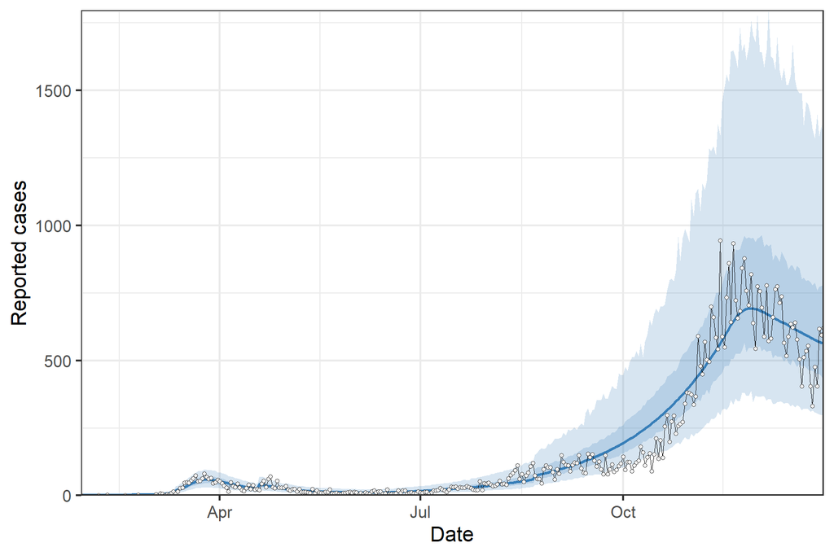

```r
project_real_dat_v1 <- project_seir(seir_real_dat_v1, iter = 1:50)

project_real_tidy_v1 <-
  tidy_seir(project_real_dat_v1, resample_y_rep = 20) %>%
  left_join(., model_input_v1, by = "day")

plot_projection(
  pred_dat     = project_real_tidy_v1,
  obs_dat      = model_input_v1,
  value_column = "daily_cases",
  date_column  = "reported_date",
) +
  theme_bw(base_size = 16) +
  labs(x = "Date")
```

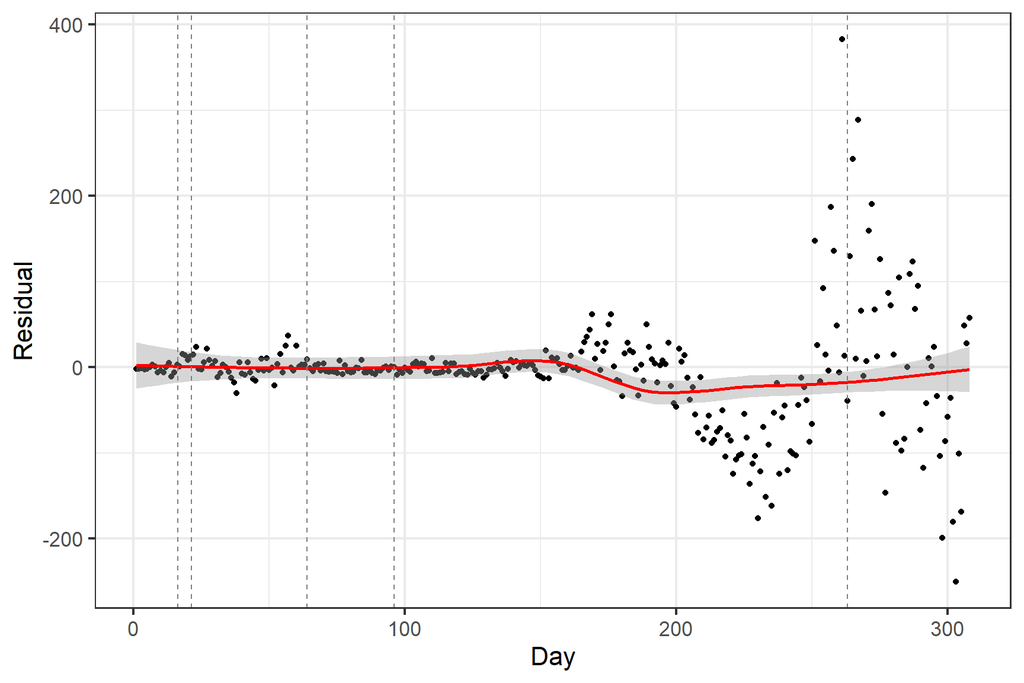

```r
plot_residuals(
  pred_dat      = project_real_tidy_v1,
  obs_dat       = model_input_v1,
  obj           = seir_real_dat_v1,
  value_column  = "daily_cases",
  date_column   = "day",
  type          = c("raw", "quantile"),
  date_function = lubridate::ymd
) +
  theme_bw(base_size = 16) +
  labs(x = "Day")
```

So we still have a problem with the residuals going crazy along with our spike in cases over the fall (BC’s second wave)…

### Attempt 2

It seems the previous estimate of R0 I was using (2.95) came from the supplemental material of a publication from the `covidseir` group. Here’s the [link](https://journals.plos.org/ploscompbiol/article?id=10.1371/journal.pcbi.1008274#sec008); I’m going to start using that value again and tweak some other parameters.

```r
model_input_v2 <- bc_data_daily_cases %>%
  filter(reported_date <= ymd("20201231")) %>%
  mutate(day = 1:nrow(.))

model_input_v2 <- model_input_v2 %>%
  mutate(
    f_seg = case_when(
      reported_date == ymd("20200129") ~ 0,
      reported_date <= ymd("20200430") ~ 1,
      reported_date <= ymd("20200531") ~ 2,
      reported_date <= ymd("20201114") ~ 3,
      reported_date <= ymd("20201231") ~ 4,
      TRUE ~ 9
    ),
    samp_frac = case_when(
      reported_date <= ymd("20200311") ~ 0.14,
      reported_date <= ymd("20200418") ~ 0.21,
      reported_date <= ymd("20200831") ~ 0.37,
      reported_date >= ymd("20200901") ~ 0.45,
      TRUE ~ 9
    )
  )

seir_real_dat_v2 <- fit_seir(
  daily_cases         = model_input_v2$daily_cases,
  f_seg               = model_input_v2$f_seg,
  samp_frac_fixed     = model_input_v2$samp_frac,
  days_back           = 60,
  i0_prior            = c(log(8), 1),
  e_prior             = c(0.8, 0.05),
  start_decline_prior = c(log(15), 0.1),
  end_decline_prior   = c(log(22), 0.1),
  f_prior             = rbind(c(0.4, 0.2), c(0.5, 0.2), c(0.6, 0.2), c(0.6, 0.2)),
  R0_prior            = c(log(2.95), 0.07),
  N_pop               = 5.1e6,
  fit_type            = "optimizing",
  iter                = 50
)
```

```
Finding the MAP estimate.
```

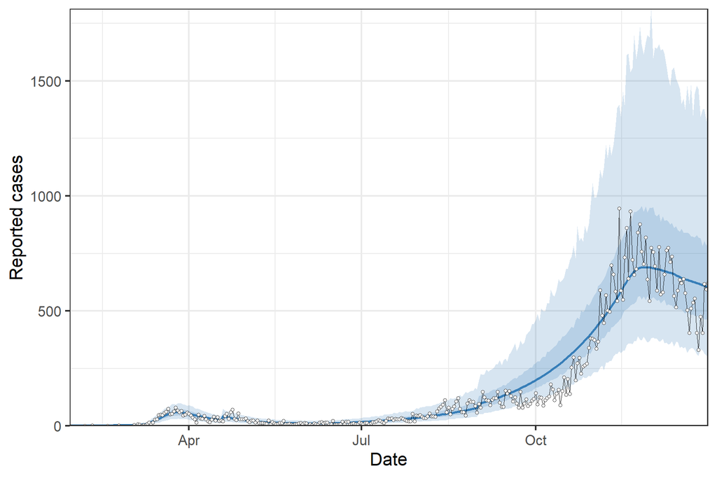

```r
project_real_dat_v2 <- project_seir(seir_real_dat_v2, iter = 1:50)

project_real_tidy_v2 <-
  tidy_seir(project_real_dat_v2, resample_y_rep = 20) %>%
  left_join(., model_input_v2, by = "day")

plot_projection(
  pred_dat     = project_real_tidy_v2,
  obs_dat      = model_input_v2,
  value_column = "daily_cases",
  date_column  = "reported_date",
) +
  theme_bw(base_size = 16) +
  labs(x = "Date")
```

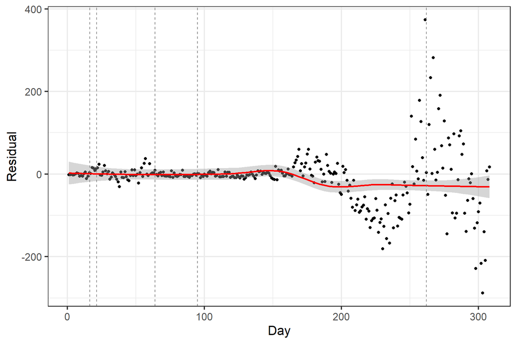

```r
plot_residuals(
  pred_dat      = project_real_tidy_v2,
  obs_dat       = model_input_v2,
  obj           = seir_real_dat_v2,
  value_column  = "daily_cases",
  date_column   = "day",
  type          = c("raw", "quantile"),
  date_function = lubridate::ymd
) +
  theme_bw(base_size = 16) +
  labs(x = "Day")
```

## Trying some projections

```r
model_input_v3 <- bc_data_daily_cases %>%
  filter(reported_date <= ymd("20201115")) %>%
  mutate(day = 1:nrow(.))

all_days_v3 <- bc_data_daily_cases %>%
  filter(reported_date <= ymd("20201231")) %>%
  mutate(day = 1:nrow(.)) %>%
  select(day, reported_date)

model_input_v3 <- model_input_v3 %>%
  mutate(
    f_seg = case_when(
      reported_date == ymd("20200129") ~ 0,
      reported_date <= ymd("20200430") ~ 1,
      reported_date <= ymd("20200531") ~ 2,
      reported_date <= ymd("20201115") ~ 3,
      TRUE ~ 9
    ),
    samp_frac = case_when(
      reported_date <= ymd("20200311") ~ 0.14,
      reported_date <= ymd("20200418") ~ 0.21,
      reported_date <= ymd("20200831") ~ 0.37,
      reported_date >= ymd("20200901") ~ 0.45,
      TRUE ~ 9
    )
  )

seir_real_dat_v3 <- fit_seir(
  daily_cases         = model_input_v3$daily_cases,
  f_seg               = model_input_v3$f_seg,
  samp_frac_fixed     = model_input_v3$samp_frac,
  days_back           = 60,
  i0_prior            = c(log(8), 1),
  e_prior             = c(0.8, 0.05),
  start_decline_prior = c(log(15), 0.1),
  end_decline_prior   = c(log(22), 0.1),
  f_prior             = rbind(c(0.4, 0.2), c(0.5, 0.2), c(0.6, 0.2)),
  R0_prior            = c(log(2.95), 0.07),
  N_pop               = 5.1e6,
  fit_type            = "optimizing",
  iter                = 50
)
```

```
Finding the MAP estimate.
```

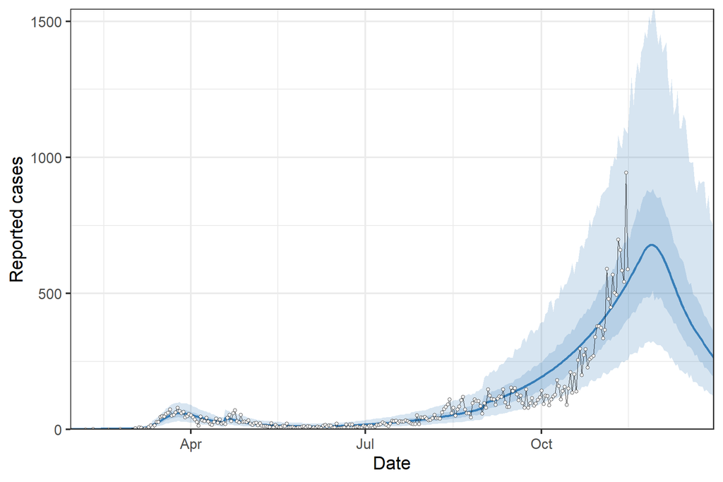

```r
project_real_dat_v3 <- project_seir(
  obj           = seir_real_dat_v3,
  iter          = 1:50,
  forecast_days = 45,
  f_fixed_start = max(seir_real_dat_v3$days) + 5,
  f_multi       = rep(0.67, 45 - 5 + 1),
  f_multi_seg   = 3
)

project_real_tidy_v3 <-
  tidy_seir(project_real_dat_v3, resample_y_rep = 20) %>%
  left_join(., all_days_v3, by = "day")

plot_projection(
  pred_dat     = project_real_tidy_v3,
  obs_dat      = model_input_v3,
  value_column = "daily_cases",
  date_column  = "reported_date",
) +
  theme_bw(base_size = 16) +
  labs(x = "Date")
```